# MATH2349 Data Wrangling

Assignment 2

CHIH-YING, HO (S3816723)

## Submission Steps:

**1** . Prepare Assignment 2 report using this R Markdown template. **Feel free to DELETE the instructional text provided in the template.**

Once you finalise your report, run all R chunks and Preview your notebook in HTML (by clicking Preview). Make sure your code and outputs are visible.

**2** . Upload the report as a PDF file via the **File Upload** tab under the Assignment 2 page in CANVAS (see instructions file for details) after you attach the file click **Submit assignment**.

The easiest way to produce a PDF file from the RMarkdown is to Run all R chunks, then Preview your notebook in HTML (by clicking Preview) → Open in Browser (Chrome) → Right click on the report in Chrome → Click Print and Select the Destination Option to Save as PDF.

**3** . Publish the report to RPubs (see [here](https://astral-theory-157510.appspot.com/secured/RBootcamp_Course_04.html#creating_an_r_markdown_document_in_r_studio)) and enter your report’s RPubs URL into the **Website URL** tab under Assignment 2 RPubs Link Submission page in Canvas (see instructions file for details) and submit this too. This online version of the report will be used for marking. Failure to submit your link will delay your feedback and risk late penalties.

**If you have any questions regarding the assignment instructions and the R Markdown template**, please post it on discussion board.

## Required packages

Provide the packages required to reproduce the report. Make sure you fulfilled the minimum requirement #10.

```r
# This is the R chunk for the required packages
library(dplyr)
library(readr)
library(tidyr)
library(knitr)
library(outliers)
library(Hmisc)
library(MVN)
library(forecast)
```

## Data

The Income by Country.csv dataset is from kaggle. It records gross domestic product (GDP) of country around the world between 1990 and 2018. The variables are: Country - the name of country 1990 ~ 2018 - Gross domestic product from 1990 to 2018

This report will only be using Country, 2016, 2017 and 2018 because Country is useful for my purpose, and 2016, 2017 and 2018 are the most recent year.

The Life_expectancy_dataset.csv file is from kaggle.It records expectancy of country, and there are 3 types of expectancy, overall, male and female expectancy. The variables are: Rank - The rank of life expectancy based on Overall Life.It will be dropped because the identifier is not useful for our purpose. This variable will be dropped because the identifier is not useful for our purpose. Country - The name of country Overall Life - The average of total life expectancy Male Life - The average of male life expectancy Female Life - The average of female life expectancy Continent - The continent that country lies in

The worldbank_classification.csv dataset is from kaggle. x - The country ID number. This variable will be dropped because the identifier is not useful for our purpose. Economy - The name of country Code - Code - ISO Alpha-3 Country code. This variable will be dropped because the identifier is not useful for our purpose. Region - The region that the country lies in. This variable will be dropped because the identifier is not useful for our purpose. Income group - Income group based on world bank classification Lending category - Lending category according to World Bank classification Other - It shows whether the country has qualified for debt-relief under the HIPC Initiative. This variable will be dropped because the identifier is not useful for our purpose.

After I import 3 dataset, I chooose the attributes using select() function and join data by Country using inner_join() function.

```r
# This is the R chunk for the Data Section
income <- read_csv("Income by Country.csv")
expectancy <- read_csv("Life_expectancy_dataset.csv")
worldbank<-read_csv("worldbank_classification.csv")
modify_income <- select(income, "Country", "2016", "2017", "2018")

modify_expectancy <- select(expectancy, 2:6)

modify_worldbank <- select(worldbank, "Economy", "Income group", "Lending category")
colnames(modify_worldbank)[1] <- "Country"

data <- inner_join(modify_income, modify_worldbank, by = "Country")
data <- inner_join(data, modify_expectancy, by = "Country")

head(data)
```

| Country | 2016 | 2017 | 2018 | Income group | Lending category | Overall Life | Male Life | Female Life | Continent |
| --- | --- | --- | --- | --- | --- | --- | --- | --- | --- |
| Afghanistan | 1766 | 1767 | 1746 | Low income | IDA | 51.3 | 49.9 | 52.7 | Asia |
| Albania | 11534 | 11831 | 12300 | Upper middle income | IBRD | 78.3 | 75.7 | 81.2 | Europe |
| Algeria | 13832 | 13656 | 13639 | Upper middle income | IBRD | 76.8 | 75.5 | 78.2 | Africa |
| Andorra | 46553 | 47550 | 48641 | High income | NA | 82.8 | 80.6 | 85.1 | Europe |
| Angola | 6051 | 5950 | 5555 | Lower middle income | IBRD | 56.0 | 54.8 | 57.2 | Africa |
| Antigua and Barbuda | 20909 | 21349 | 22201 | High income | IBRD | 76.5 | 74.4 | 78.8 | North America |

## Understand

The type of variables are character or numeric. The data structure is dataframe. I convert variables 2016, 2017 and 2018 into numeric type using as.numeric() function. Besides, I convert variable Continent into factor type and order it.

```r
# This is the R chunk for the Understand Section
str(data)
```

```
tibble [158 x 10] (S3: tbl_df/tbl/data.frame)
 $ Country         : chr [1:158] "Afghanistan" "Albania" "Algeria" "Andorra" ...
 $ 2016            : chr [1:158] "1766" "11534" "13832" "46553" ...
 $ 2017            : chr [1:158] "1767" "11831" "13656" "47550" ...
 $ 2018            : chr [1:158] "1746" "12300" "13639" "48641" ...
 $ Income group    : chr [1:158] "Low income" "Upper middle income" "Upper middle income" "High income" ...
 $ Lending category: chr [1:158] "IDA" "IBRD" "IBRD" NA ...
 $ Overall Life    : num [1:158] 51.3 78.3 76.8 82.8 56 76.5 77.1 74.6 82.2 81.5 ...
 $ Male Life       : num [1:158] 49.9 75.7 75.5 80.6 54.8 74.4 74 71.4 79.8 78.9 ...
 $ Female Life     : num [1:158] 52.7 81.2 78.2 85.1 57.2 78.8 80.4 78.3 84.8 84.3 ...
 $ Continent       : chr [1:158] "Asia" "Europe" "Africa" "Europe" ...
```

```r
class(data)
```

```
[1] "tbl_df"     "tbl"        "data.frame"
```

```
tbl_df

tbl

data.frame
```

```r
colnames(data)
```

```
 [1] "Country"          "2016"             "2017"             "2018"
 [5] "Income group"     "Lending category" "Overall Life"     "Male Life"
 [9] "Female Life"      "Continent"
```

```
Country

2016

2017

2018

Income group

Lending category

Overall Life

Male Life

Female Life

Continent
```

```r
data[, 2:4] <- sapply(data[, 2:4], as.numeric)
str(data)
```

```
tibble [158 x 10] (S3: tbl_df/tbl/data.frame)
 $ Country         : chr [1:158] "Afghanistan" "Albania" "Algeria" "Andorra" ...
 $ 2016            : num [1:158] 1766 11534 13832 46553 6051 ...
 $ 2017            : num [1:158] 1767 11831 13656 47550 5950 ...
 $ 2018            : num [1:158] 1746 12300 13639 48641 5555 ...
 $ Income group    : chr [1:158] "Low income" "Upper middle income" "Upper middle income" "High income" ...
 $ Lending category: chr [1:158] "IDA" "IBRD" "IBRD" NA ...
 $ Overall Life    : num [1:158] 51.3 78.3 76.8 82.8 56 76.5 77.1 74.6 82.2 81.5 ...
 $ Male Life       : num [1:158] 49.9 75.7 75.5 80.6 54.8 74.4 74 71.4 79.8 78.9 ...
 $ Female Life     : num [1:158] 52.7 81.2 78.2 85.1 57.2 78.8 80.4 78.3 84.8 84.3 ...
 $ Continent       : chr [1:158] "Asia" "Europe" "Africa" "Europe" ...
```

```r
data$Continent <- as.factor(data$Continent)
data$Continent <- ordered(data$Continent, levels = c("Europe", "Africa", "Asia","Oceania","North America", "South"," America" ))

class(data$Continent)
```

```
[1] "ordered" "factor"
```

```
ordered

factor
```

```r
levels(data$Continent)
```

```
[1] "Europe"        "Africa"        "Asia"          "Oceania"
[5] "North America" "South"         " America"
```

```
Europe

Africa

Asia

Oceania

North America

South

 America
```

## Tidy & Manipulate Data I

The data is untidy because the column names called 2016, 2017, 2018, Males and Female are values, not variable names. I use gather() function to reshape the dataset into a tidy format.

```r
# This is the R chunk for the Tidy & Manipulate Data I
data1 <- data %>% gather(`2016`, `2017`, `2018`, key = "year", value = "Income")

colnames(data1)[5] <- "Male"
colnames(data1)[6] <- "Female"

data2 <- data1 %>% gather(`Male`, `Female`, key = "gender", value = "Life expectancy")
```

## Tidy & Manipulate Data II

I create new variable called Difference_expectancy using mutate() function.

```r
# This is the R chunk for the Tidy & Manipulate Data II
# Create new variables "difference of expectancy"
data2 <- mutate(data2,
        Difference_expectancy = `Overall Life` - `Life expectancy`)
```

## Scan I

In my data, there are 204 missing values for categorical variables called Lending category and Continent . I deal with missing values using imputation techniques, rather excluding missing values, because omitting missing values might cause biased data. I replace them with modes using Hmisc package.

```r
# This is the R chunk for the Scan I
is.na(data2$Country)
```

[output not shown]

[output cut: 64 more lines]

```r
which(is.na(data2$Country))
```

```
integer(0)
```

```r
which(is.na(data2$`Income group`))
```

```
integer(0)
```

```r
which(is.na(data2$`Lending category`))
```

```
  [1]   4   9  12  14  29  37  39  64  65  70  73  78  84 104 108 109 119 123
 [19] 128 136 137 150 151 152 162 167 170 172 187 195 197 222 223 228 231 236
 [37] 242 262 266 267 277 281 286 294 295 308 309 310 320 325 328 330 345 353
 [55] 355 380 381 386 389 394 400 420 424 425 435 439 444 452 453 466 467 468
 [73] 478 483 486 488 503 511 513 538 539 544 547 552 558 578 582 583 593 597
 [91] 602 610 611 624 625 626 636 641 644 646 661 669 671 696 697 702 705 710
[109] 716 736 740 741 751 755 760 768 769 782 783 784 794 799 802 804 819 827
[127] 829 854 855 860 863 868 874 894 898 899 909 913 918 926 927 940 941 942
```

```r
which(is.na(data2$`Overall Life`))
```

```
integer(0)
```

```r
which(is.na(data2$Continent))
```

```
 [1]   7  22  32  33  43  61 114 115 135 153 165 180 190 191 201 219 272 273 293
[20] 311 323 338 348 349 359 377 430 431 451 469 481 496 506 507 517 535 588 589
[39] 609 627 639 654 664 665 675 693 746 747 767 785 797 812 822 823 833 851 904
[58] 905 925 943
```

```r
which(is.na(data2$year))
```

```
integer(0)
```

```r
which(is.na(data2$Income))
```

```
integer(0)
```

```r
which(is.na(data2$gender))
```

```
integer(0)
```

```r
which(is.na(data2$`Life expectancy`))
```

```
integer(0)
```

```r
which(is.na(data2$Difference_expectancy))
```

```
integer(0)
```

```r
sum(is.na(data2$Continent))
```

```
[1] 60
```

```r
sum(is.na(data2$`Lending category`))
```

```
[1] 144
```

```r
data2$`Lending category` <- impute(data2$`Lending category`, fun = mode)
data2$`Continent` <- impute(data2$`Continent`, fun = mode)
```

## Scan II

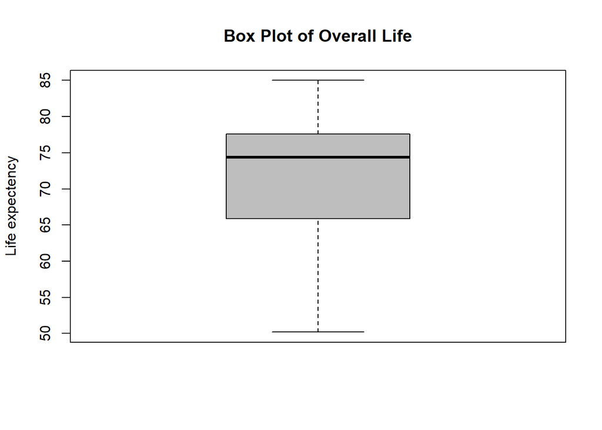

```r
# This is the R chunk for the Scan II
boxplot(data2$`Overall Life`, main = "Box Plot of Overall Life", ylab = "Life expectency", col = "grey")
```

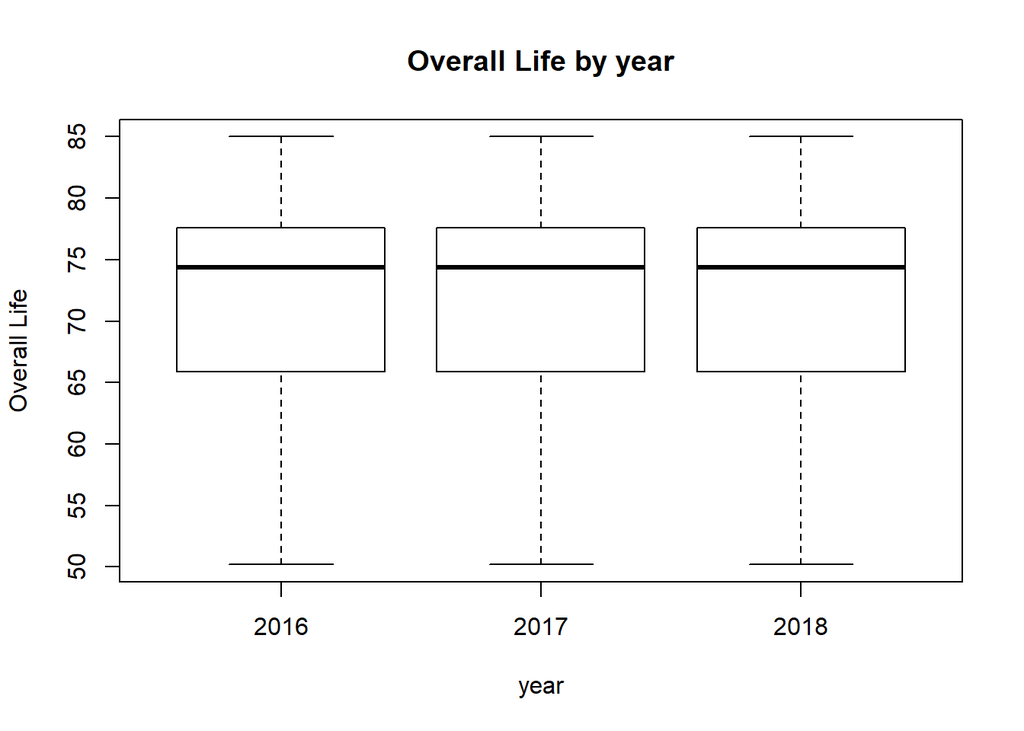

```r
boxplot(data2$`Overall Life` ~ data2$year, main="Overall Life by year", ylab = "Overall Life", xlab = "year")
```

```r
z.scores_OverallLife <- data2$`Overall Life` %>%  scores(type = "z")
z.scores_OverallLife %>% summary()
```

```
   Min. 1st Qu.  Median    Mean 3rd Qu.    Max.
-2.4948 -0.6630  0.3288  0.0000  0.7021  1.5656
```

```r
which( abs(z.scores_OverallLife) >3 )
```

```
integer(0)
```

```r
length (which( abs(z.scores_OverallLife) >3 ))
```

```
[1] 0
```

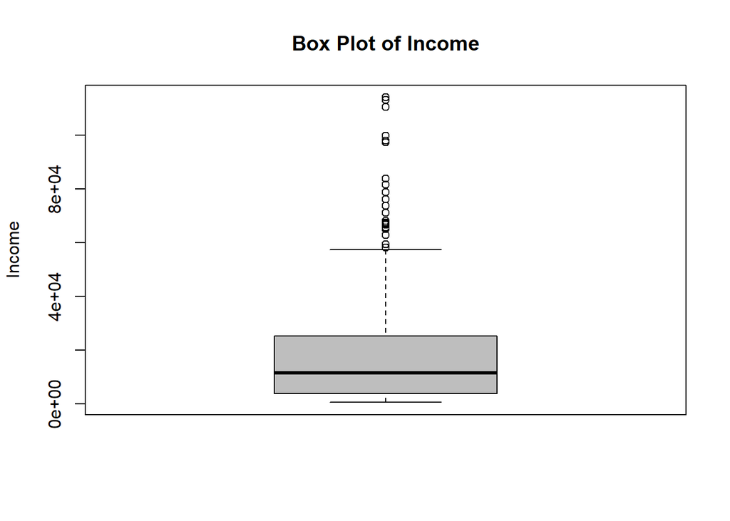

```r
boxplot(data2$Income, main = "Box Plot of Income", ylab = "Income", col = "grey")
```

```r
z.scores_Income <- data2$Income %>%  scores(type = "z")
z.scores_Income %>% summary()
```

```
   Min. 1st Qu.  Median    Mean 3rd Qu.    Max.
-0.9029 -0.7354 -0.3497  0.0000  0.3430  4.8044
```

```r
which( abs(z.scores_Income) >3 )
```

```
 [1]  84 119 128 242 277 286 400 435 444 558 593 602 716 751 760 874 909 918
```

```r
length (which( abs(z.scores_Income) >3 ))
```

```
[1] 18
```

```r
for(i in 1:5){
# remove outliers
data2 <- data2[- which( abs(z.scores_Income) >3 ), ]
}
#check again
z.scores_Income <- data2$Income %>%  scores(type = "z")
z.scores_Income %>% summary()
```

```
   Min. 1st Qu.  Median    Mean 3rd Qu.    Max.
-0.9925 -0.7917 -0.3315  0.0000  0.4671  3.5902
```

```r
which( abs(z.scores_Income) >3 )
```

```
 [1]  78 103 135 221 246 279 364 390 424 507 534 569 650 678 712 793 821 857
```

```r
length (which( abs(z.scores_Income) >3 ))
```

```
[1] 18
```

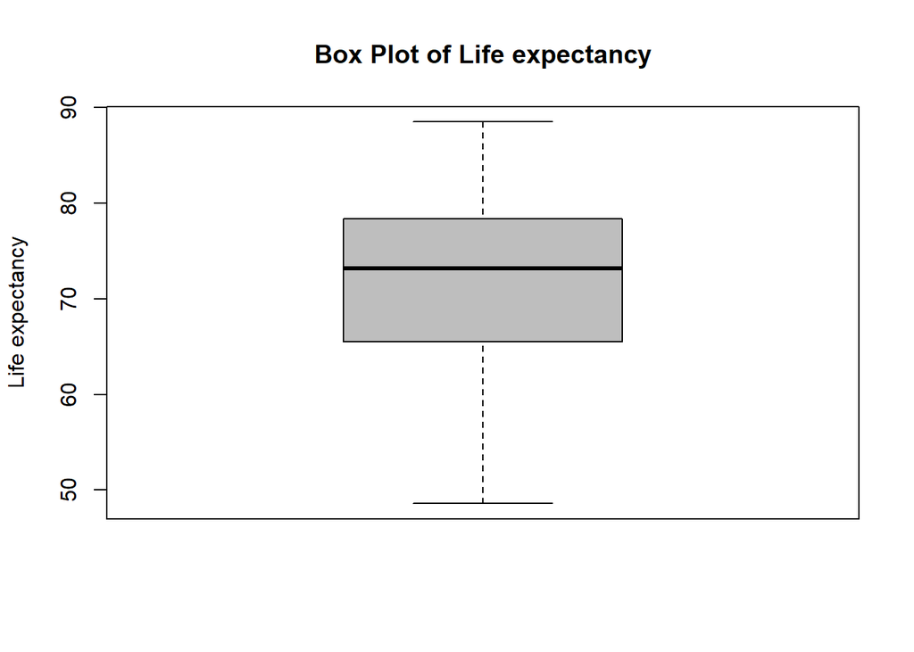

```r
boxplot(data2$`Life expectancy`, main = "Box Plot of Life expectancy", ylab = "Life expectancy", col = "grey")
```

```r
z.scores_Life_expectancy <- data2$`Life expectancy` %>%  scores(type = "z")
z.scores_Life_expectancy %>% summary()
```

```
   Min. 1st Qu.  Median    Mean 3rd Qu.    Max.
-2.5455 -0.6647  0.1922  0.0000  0.7710  1.8950
```

```r
which( abs(z.scores_Life_expectancy) >3 )
```

```
integer(0)
```

```r
length (which( abs(z.scores_Life_expectancy) >3 ))
```

```
[1] 0
```

## Transform

The variable Income is the distribution of right skewness. I use square root transformation to reduce right skewness. Then, I use Box-Cox Transformation to transform data into a normal distribution.

The distribution of Overall Life is left skewed. I use square transformation to reduce left skewness. Then, I use Box-Cox Transformation to convert data into a normal distribution.

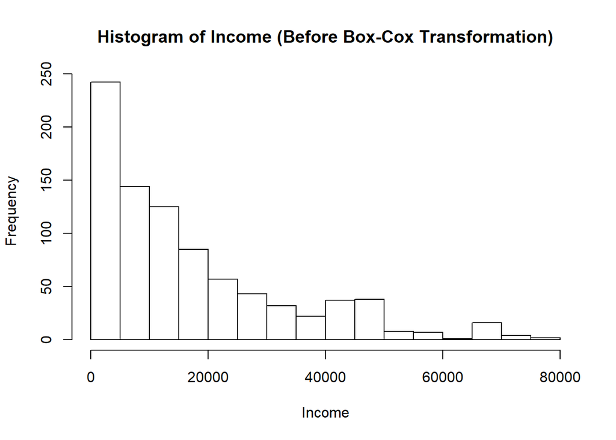

```r
# This is the R chunk for the Transform Section
## Before Box-Cox Transformation
hist(data2$Income, main = "Histogram of Income (Before Box-Cox Transformation)", xlab = "Income")
```

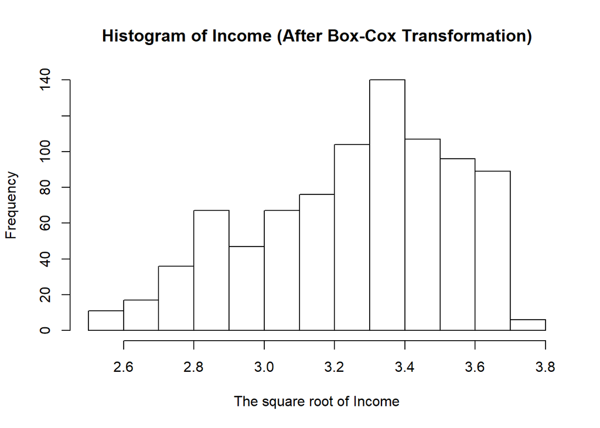

```r
data2$Income <- sqrt(data2$Income)
data2$Income <- BoxCox(data2$Income,lambda = "auto")

#After Box-Cox Transformation
hist(data2$Income, main = "Histogram of Income (After Box-Cox Transformation)", xlab = "The square root of Income")
```

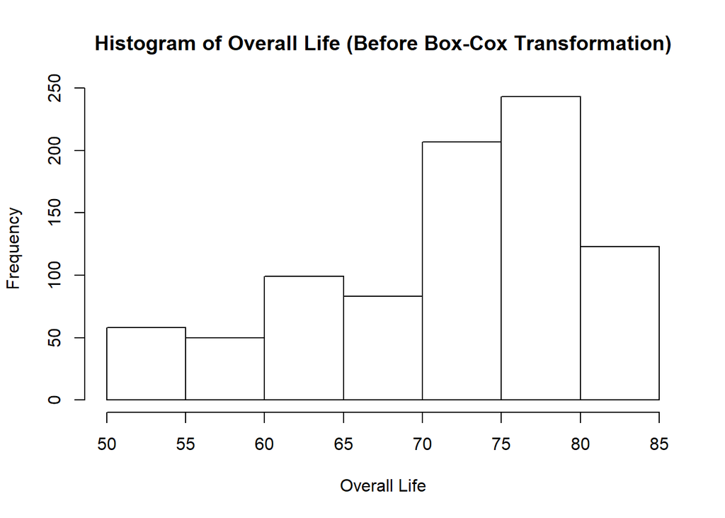

```r
## Before Box-Cox Transformation
hist(data2$`Overall Life`, main = "Histogram of Overall Life (Before Box-Cox Transformation)", xlab = "Overall Life")
```

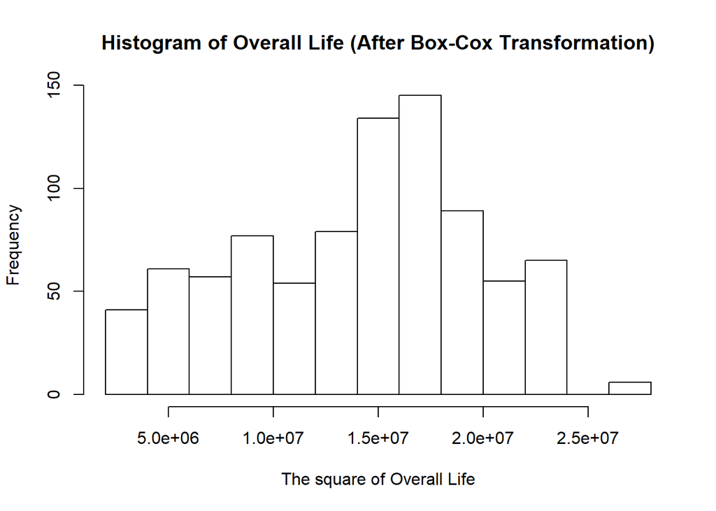

```r
data2$`Overall Life` <- (data2$`Overall Life`)^2
data2$`Overall Life` <- BoxCox(data2$`Overall Life`,lambda = "auto")

#After Box-Cox Transformation
hist(data2$`Overall Life`, main = "Histogram of Overall Life (After Box-Cox Transformation)", xlab = "The square of Overall Life")
```

## Reference

Kaggle 2020, Income by Country, Kaggle, viewed 22 Sep 2014, https://www.kaggle.com/frankmollard/income-by-country

Kaggle 2019, World Bank Country and Lending Groups Country Classification, Kaggle, viewed 22 Sep 2014, https://www.kaggle.com/taniaj/world-bank-country-and-lending-groups

Kaggle 2017, Life Expectancy of the World, Kaggle, viewed 22 Sep 2014, https://www.kaggle.com/amansaxena/lifeexpectancy

World Health Organization 2014, WHO recommendations for routine immunization - summary tables, World Health Organization, viewed 1 May 2014, http://www.who.int/immunization/policy/immunization_tables/en/

Sona Taheri, 2020, ‘Week 2 Demonstration.pdf’ lecture notes, COSC2111, RMIT University, Melbourne

Sona Taheri, 2020, ‘Week 2 - Class Worksheet.pdf’ lecture notes, COSC2111, RMIT University, Melbourne

Sona Taheri, 2020, ‘Week 3 Demonstration.pdf’ lecture notes, COSC2111, RMIT University, Melbourne

Sona Taheri, 2020, ‘Week 3 - Class Worksheet.pdf’ lecture notes, COSC2111, RMIT University, Melbourne

Sona Taheri, 2020, ‘Week 4 Demonstration.pdf’ lecture notes, COSC2111, RMIT University, Melbourne

Sona Taheri, 2020, ‘Week 4 - Class Worksheet.pdf’ lecture notes, COSC2111, RMIT University, Melbourne

Sona Taheri, 2020, ‘Week 5 Demonstration.pdf’ lecture notes, COSC2111, RMIT University, Melbourne

Sona Taheri, 2020, ‘Week 5 - Class Worksheet.pdf’ lecture notes, COSC2111, RMIT University, Melbourne

Sona Taheri, 2020, ‘Week 6 Demonstration.pdf’ lecture notes, COSC2111, RMIT University, Melbourne

Sona Taheri, 2020, ‘Week 6 - Class Worksheet.pdf’ lecture notes, COSC2111, RMIT University, Melbourne

Sona Taheri, 2020, ‘Week 7 Demonstration.pdf’ lecture notes, COSC2111, RMIT University, Melbourne

Sona Taheri, 2020, ‘Week 7 - Class Worksheet.pdf’ lecture notes, COSC2111, RMIT University, Melbourne

Sona Taheri, 2020, ‘Week 8 Demonstration.pdf’ lecture notes, COSC2111, RMIT University, Melbourne

Sona Taheri, 2020, ‘Week 8 - Class Worksheet.pdf’ lecture notes, COSC2111, RMIT University, Melbourne

Sona Taheri, 2020, ‘Week 9 Demonstration.pdf’ lecture notes, COSC2111, RMIT University, Melbourne

Sona Taheri, 2020, ‘Week 9 - Class Worksheet.pdf’ lecture notes, COSC2111, RMIT University, Melbourne